# Walmart Customer Trip Type Classification

[video not shown]

### 1. 분석목적 (Purpose of Analysis)

Walmart Recruiting: Trip Type Classification 이용, Walmart 소비자 패턴을 분석하여 범주화된 Trip Type에 해당되는 VisitNumber 예측 및 분류.

### 2. 사용한 라이브러리

```
## funModeling v.1.6.5 :)
## Examples and tutorials at livebook.datascienceheroes.com
```

#### 수정 전 데이터

```r
wal_dataset <- read.csv("C:/Users/rudghksldl/Desktop/train 3.csv")

head(wal_dataset, 20)
```

```
##    TripType VisitNumber Weekday         Upc ScanCount
## 1       999           5  Friday 68113152929        -1
## 2        30           7  Friday 60538815980         1
## 3        30           7  Friday  7410811099         1
## 4        26           8  Friday  2238403510         2
## 5        26           8  Friday  2006613744         2
## 6        26           8  Friday  2006618783         2
## 7        26           8  Friday  2006613743         1
## 8        26           8  Friday  7004802737         1
## 9        26           8  Friday  2238495318         1
## 10       26           8  Friday  2238400200        -1
## 11       26           8  Friday  5200010239         1
## 12       26           8  Friday 88679300501         2
## 13       26           8  Friday 22006000000         1
## 14       26           8  Friday  2236760452         1
```

[output cut: 27 more lines]

### 변수 설명

TripType - a categorical id representing the type of shopping trip the customer made. This is the ground truth that you are predicting. TripType_999 is an “other” category. VisitNumber - an id corresponding to a single trip by a single customer  
Weekday - the weekday of the trip  
Upc - the UPC number of the product purchased  
ScanCount - the number of the given item that was purchased. A negative value indicates a product return.  
DepartmentDescription - a high-level description of the item’s department  
FinelineNumber - a more refined category for each of the products, created by Walmart

### 변수 변환

```r
dt <- na.omit(read.csv("C:/Users/rudghksldl/Desktop/newdata (1).csv"))
dt <- dt[ ,c(-1,-2,-5,-6)]
dt$triptype <- as.factor(dt$triptype)
glimpse(dt)
```

```
## Observations: 94,247
## Variables: 74
## $ num_prod                    <int> -1, 2, 28, 3, 3, 4, 7, 9, 4, 9, 3,...
## $ weekday                     <fctr> Friday, Friday, Friday, Friday, F...
## $ TotalDescCount              <int> 1, 2, 22, 3, 3, 4, 7, 8, 4, 9, 2, ...
## $ max_prodrate                <dbl> 1.000, 0.500, 0.727, 0.667, 0.667,...
## $ X1.HR.PHOTO                 <int> 0, 0, 0, 0, 0, 0, 0, 0, 0, 0, 0, 0...
## $ ACCESSORIES                 <int> 0, 0, 0, 0, 0, 0, 0, 0, 0, 1, 0, 0...
## $ AUTOMOTIVE                  <int> 0, 0, 0, 0, 0, 0, 0, 0, 0, 0, 0, 0...
## $ BAKERY                      <int> 0, 0, 0, 0, 0, 0, 0, 0, 0, 0, 0, 0...
## $ BATH.AND.SHOWER             <int> 0, 0, 0, 0, 0, 0, 0, 0, 0, 0, 0, 0...
## $ BEAUTY                      <int> 0, 0, 0, 0, 0, 0, 0, 0, 0, 0, 0, 0...
## $ BEDDING                     <int> 0, 0, 0, 0, 0, 0, 0, 0, 0, 0, 0, 0...
## $ BOOKS.AND.MAGAZINES         <int> 0, 0, 0, 0, 0, 0, 0, 0, 0, 0, 0, 0...
## $ BOYS.WEAR                   <int> 0, 0, 0, 0, 0, 0, 2, 0, 0, 0, 0, 0...
```

[output cut: 61 more lines]

### 새로 만든 변수 설명

id - 고객 고유값  
num_prod - 구매 + 환불(-)  
weekday - 방문요일  
RefundCount - 고객의 총 환불량  
TotalDescCount - 고객의 총 구매량  
MaxDescCount - 최대값을 갖는 DepartmentDescription의 양  
max_prodrate - 최대값을 갖는 DepartmentDescription의 해당비율

DepartmentDescription의 dummy 변수(one hot 인코딩) - 68열

TripType - 예측해야할 타겟 변수

#### 4. Model Accuracy 판단

```r
# train / validation data
trn_idx <- sample(1:dim(dt)[1], round(0.7*dim(dt)[1]))
w_trn <- dt[trn_idx, ]
w_val <- dt[-trn_idx, ]
```

### 4.1 KNN

```r
w_knn <- kknn(triptype ~ .,
              w_trn,
              w_val,
              k = 7,
              distance = 2,
              kernel = "rectangular")
```

모델 적합 후 정확도 확인

```r
pima_knn_fit <- fitted(w_knn)
pima_knn_cf <- confusionMatrix(w_val$triptype, as.factor(pima_knn_fit))
pima_knn_cf
```

```
## Confusion Matrix and Statistics
##
##           Reference
## Prediction    3    4    5    6    7    8    9   12   14   15   18   19
##        3   1020    0    0    1    0   29    7    0    0    0    0    0
##        4      1    2   78    0    1    7    2    0    0    0    0    0
##        5      6    5  731    6   22   71   40    0    0    1    2    1
##        6      1    0    1  274    6   58    3    0    0    0    0    1
##        7      3    0   10    8 1208  220   24    1    0    3    2    0
##        8      7    0  111   70  194 2917  133    0    0    0    0    0
##        9     20    0   15    2   12  140 2102    3    0    9   16   31
##        12     0    0    0    1    9    3   10    3    0    1    2    0
##        14     0    0    0    0    0    0    0    0    0    0    0    0
##        15     2    0    3    1    8   47   49    1    0   97    1    0
##        18     0    0    0    0    0    9   49    0    0    1   66    0
##        19     0    0    0    0    0    0   43    0    0    0    1   28
##        20     1    0    2    1    1    1   69    0    0    1    0    0
##        21     0    0    2    1    1    3   46    0    0    5    2    1
##        22     2    0    2    0    0    0   91    0    0    0    1   22
##        23     2    0    0    0    0    0   22    0    0    0    0    0
##        24     5    0    3    4    7    9  151    0    0    3    1    1
##        25     8    0    3    6    5    7  175    2    0    0    2    0
##        26     2    0    1    0    1    1   57    0    0    1    0    0
##        27     3    0    1    2    2    2   55    3    0    1    2    0
##        28     1    0    2    0    2    0   63    0    0    0    0    0
##        29     3    0    4    0    0    2   51    0    0    0   13    1
##        30     2    0    2    1    2    2  123    0    0    0    0    0
##        31     4    0    0    1    0    4   36    0    0    0    0    0
##        32     5    0    6    3    9   44   31    1    0    3    6    0
##        33     3    0    0    1    6   62   11    0    0    0    0    0
##        34     1    0    2    4    4   37   12    0    0    0    0    0
##        35    11    0   12    7   34  140   28    0    0    2    4    1
##        36    10    0   44    4    7  115   35    0    0    3    2    0
##        37     6    0    8    1  126   71   13    0    0    5    1    4
##        38     2    0    5    7   80  107   20    0    0    0    2    0
##        39    21    0  115   72  292  191  130    8    0   22   13    4
##        40     0    1   14    3   22    2    4    3    0    4    4    0
##        41     1    0    1    0    0    0   36    0    0    1    3    3
##        42     2    0    1    3    2    7   85    1    0   26   18    3
##        43     7    0    5    1    2   11   62    3    0    8    6    0
```

[output cut: 192 more lines]

```
## Pos Pred Value         0.38269   0.37336   0.49755 1.130e-02  0.067376
## Neg Pred Value         0.98613   0.95150   0.99323 9.994e-01  0.997005
## Prevalence             0.02532   0.08266   0.03866 6.720e-04  0.004280
## Detection Rate         0.01188   0.03926   0.03233 7.074e-05  0.001344
## Detection Prevalence   0.03105   0.10515   0.06497 6.260e-03  0.019948
## Balanced Accuracy      0.72480   0.70157   0.90114 5.495e-01  0.647683
##                      Class: 43 Class: 44 Class: 999
## Sensitivity          0.1025641 0.2187500    0.80103
## Specificity          0.9911812 0.9882445    0.95207
## Pos Pred Value       0.0158103 0.0206490    0.49187
## Neg Pred Value       0.9987509 0.9991051    0.98804
## Prevalence           0.0013794 0.0011318    0.05475
## Detection Rate       0.0001415 0.0002476    0.04386
## Detection Prevalence 0.0089482 0.0119898    0.08916
## Balanced Accuracy    0.5468726 0.6034972    0.87655
```

### 4.2 RandomForest

최적의 파라미터를 찾기 위한 그리드 서치

```r
## 하이퍼 파라미터 정의
ntree = c(10, 20)
mtry = c(3, 5, 10)


# 결과값 넣을 메트릭스
tree_result <- matrix(0, length(ntree)*length(mtry),6)
iter_cnt = 1
i = 1
j = 1


# 위 파라미터들 다 넣는 포문
for(i in 1:length(ntree)){
  for(j in 1:length(mtry)){
    cat("ntree : ", ntree[i],
        ", mtry : ", mtry[j],
        "\n")


    ## 위 파라미터로 RF 모형 적합

    tmp_rf <- randomForest(triptype ~ .,
                           data = w_trn,
                           ntree = ntree[i],
                           mtry = mtry[j]
    )

    ## 위 적합으로 검증데이터 예측 수행
    tmp_tree_val_pred <- predict(tmp_rf, newdata = w_val, type = "class")


    ## 혼동행렬 작성
    tmp_tree_val_cf <- confusionMatrix(as.factor(tmp_tree_val_pred), w_val$triptype)

    ## AUROC


    ### 조건들 저장
    tree_result[iter_cnt, 1] = ntree[i]
    tree_result[iter_cnt, 2] = mtry[j]
    tree_result[iter_cnt, 3] = tmp_tree_val_cf$byClass['Recall']
    tree_result[iter_cnt, 4] = tmp_tree_val_cf$byClass['Precision']
    tree_result[iter_cnt, 5] = tmp_tree_val_cf$overall['Accuracy']
    tree_result[iter_cnt, 6] = tmp_tree_val_cf$byClass['F1']




    iter_cnt = iter_cnt +1
  }
}
```

```
## ntree :  10 , mtry :  3
## ntree :  10 , mtry :  5
## ntree :  10 , mtry :  10
## ntree :  20 , mtry :  3
## ntree :  20 , mtry :  5
## ntree :  20 , mtry :  10
```

```r
colnames(tree_result) <-  c("ntree", "mtry", "Recall", "Precision", "Accuracy",
                            "F1")


# 어큐러시 와  F1 지표를 기준으로 정렬
tree_result.df <- data.frame(tree_result)
tree_result.df <- tree_result.df[order(tree_result.df[,5],tree_result.df[,6],decreasing = T),]
head(tree_result.df)
```

```
##   ntree mtry Recall Precision  Accuracy F1
## 6    20   10     NA        NA 0.6687770 NA
## 5    20    5     NA        NA 0.6626229 NA
## 3    10   10     NA        NA 0.6569286 NA
## 2    10    5     NA        NA 0.6523661 NA
## 4    20    3     NA        NA 0.6287402 NA
## 1    10    3     NA        NA 0.6092523 NA
```

최적조건으로 최종적합

```r
# 최적 조건으로 학습나무를 학습 with 전체 데이터
tree <- randomForest(triptype ~ .,
                     data = w_trn ,
                     ntree = 20,
                     mtry = 10)

tree_all_prediction <- predict(tree, newdata = w_val)

# 최종 완성된 결정나무의 분류 성능 확인
tree_all_cm <- confusionMatrix(tree_all_prediction, w_val$triptype)
tree_all_cm
```

```
## Confusion Matrix and Statistics
##
##           Reference
## Prediction    3    4    5    6    7    8    9   12   14   15   18   19
##        3   1038    0    0    0    0    0   20    0    0    2    1    0
##        4      0    0    0    0    0    0    0    0    0    0    0    0
##        5      0   87  727    3    7  112   32    1    0    3    0    1
##        6      0    0    4  236    6   77    2    0    0    0    0    1
##        7      0    0   11   12 1117  143   31    3    0    6    1    1
##        8     42    3   48   34  191 3092  233    1    0   27    9    0
##        9      1    0   17    4    8   85 2261    4    0    9   35   66
##        12     0    0    1    0    0    0    0    0    0    1    0    0
##        14     0    0    0    0    0    0    0    0    0    0    0    0
##        15     0    0    1    0    2    1    2    3    0  110    1    0
##        18     0    0    0    0    0    1    3    4    0    1   51    1
##        19     0    0    0    0    0    1    9    0    0    0    0   15
##        20     0    0    1    0    0    0    2    0    0    0    4    0
##        21     0    0    2    1    1    1    5    1    2    5    4    1
##        22     2    0    0    0    0    0   19    0    0    0    0   19
##        23     0    0    0    0    0    0   10    0    0    0    0    1
##        24     6    0    3    3    7    5   20    3    0    5    6    2
##        25     2    0    7    1    5    2   41    1    0    6    7    4
##        26     0    0    0    0    0    0    1    0    0    1    0    1
##        27     1    0    0    0    1    1    1    9    0    1    0    0
##        28     0    0    0    0    0    0    2    0    0    1    0    0
##        29     0    0    0    0    0    0    5    0    0    0    3    0
##        30     1    0    1    0    2    2   17    0    0    4    0    0
##        31     0    0    0    0    0    2   62    0    0    1    0    0
##        32     0    0    0    0    4   63   40    1    0    4    5    0
##        33     0    1    2    4    4    4    1    8    0    7    2    0
##        34     0    0    2    0    1    3    1    0    0    0    1    1
##        35     1    0    7    9    8    5    2    3    0   17    7    0
##        36     1    1   34    2    2   17    3    2    0    4    5    2
##        37     0    0    5    6   64    5    2    5    0   10    1    1
##        38     1    0    4    2   41   25    3    1    0    3    1    2
##        39     2    6  100   49  208   11    1   28    0   54   19    7
##        40     0    0    6    2    5    0    0    7    0    9    2    0
##        41     0    0    0    0    0    0    1    0    0    0    1    0
##        42     0    0    1    1    0    1    2    2    0    4   12    2
##        43     0    0    0    0    0    0    0    0    0    1    1    0
```

[output cut: 192 more lines]

```
## Pos Pred Value         0.51067   0.49445   0.74651 0.1578947  0.380597
## Neg Pred Value         0.98034   0.96681   0.99313 0.9938418  0.983504
## Prevalence             0.03105   0.10515   0.06497 0.0062602  0.019948
## Detection Rate         0.01185   0.07714   0.05864 0.0001061  0.003608
## Detection Prevalence   0.02320   0.15601   0.07855 0.0006720  0.009479
## Balanced Accuracy      0.68492   0.82273   0.94063 0.5081898  0.587430
##                      Class: 43 Class: 44 Class: 999
## Sensitivity          0.0355731 0.0353982    0.74653
## Specificity          0.9988580 0.9983175    0.99915
## Pos Pred Value       0.2195122 0.2033898    0.98845
## Neg Pred Value       0.9913576 0.9884104    0.97577
## Prevalence           0.0089482 0.0119898    0.08916
## Detection Rate       0.0003183 0.0004244    0.06656
## Detection Prevalence 0.0014501 0.0020867    0.06734
## Balanced Accuracy    0.5172156 0.5168579    0.87284
```

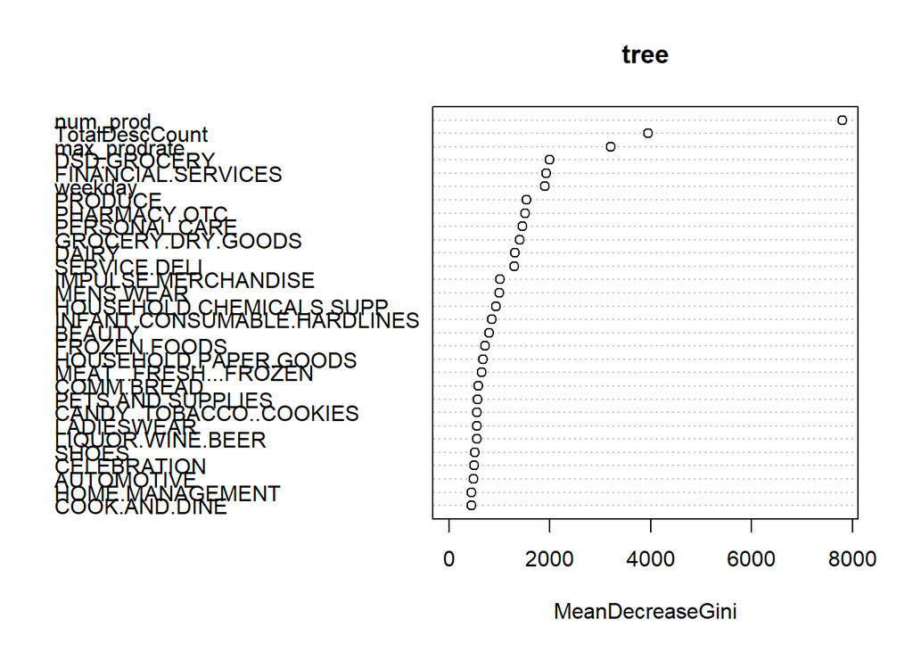

```r
# 시각화
varImpPlot(tree)
```

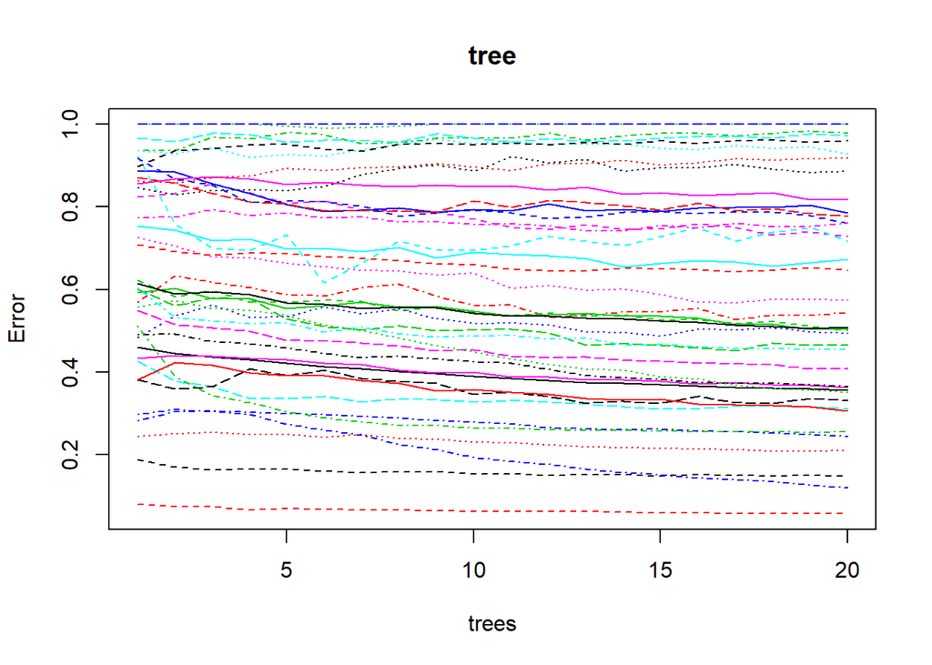

```r
plot(tree)
```

#### 5. 설정 모델로 예측 및 평가